# Ciberseguridad en estudiantes de licenciatura

Objetivos y preguntas

Equipo 1: Diego Arellano, Emilio Ramírez, Fernanda Monter, Fernando Lango

24/11/2021

# 1 Objetivos

## 1.1 Objetivo Principal

- Conocer la percepción de ciberseguridad entre estudiantes de licenciatura.

## 1.2 Objetivos específicos

- Conocer los usos y necesidades de tecnología de la población estudiantil (Redes sociales).
- Estudiar y analizar que tanto se conoce de la ciberseguridad (Ciberseguridad).
- Analizar la percepción de amenazas y ataques digitales (Privacidad y Ciberseguridad).
- Conocer las medidas de seguridad más utilizadas (Privacidad).

## 1.3 ¿Qué queremos medir?

- La importancia que los estudiantes de licenciatura dan a la ciberseguridad en internet.

# 2 Preguntas

## 2.1 Demografía

Con estas primeras preguntas pretendemos conocer un poco más a nuestra población y filtrar que solamente estudiantes de licenciatura contesten la encuesta.

- ¿Eres alumno de licenciatura?
  - Si
  - No

En caso de responder que no, finalizara automáticamente la encuesta. Dentro de nuestro plan de difusión de la encuesta tomaremos todas las medidas necesarias para que transite únicamente entre estudiantes de licenciatura. Sin embargo, ponemos esta pregunta para asegurarnos y tener una encuesta válida para el estudio.

- ¿Qué edad tienes?
  - int
- Género
  - Masculino
  - Femenino
  - Otros
- ¿En qué estado se encuentra ubicada tu Universidad?
  - Estados de la República

Ya que uno de los integrantes del equipo es de Querétaro y la difundirá con sus conocidos nos es importante notar esta diferencia y creemos que nos será útil para el análisis tener una visión más amplia. También puede que quienes la contesten por redes no vivan en la CDMX

- ¿A qué área corresponde tu carrera?
  - Físico Matemático y de la Ingeniería
  - Biológicas y de la salud
  - Sociales
  - Artes y Humanidades

## 2.2 Exploratorias

- ¿Del 1 al 5 que tanto te preocupa tu seguridad digital?
  - Escala de 1 a 5 (Escala de Likert)
- ¿Sabes en qué consiste la privacidad digital?
  - Sí
  - No
- ¿Conoces el término de huella digital?
  - Sí
  - No

## 2.3 Vulnerabilidad

- ¿Cuántos dispositivos con acceso internet tienes?
  - int

De esta manera mediremos la vulnerabilidad de cada persona.

- ¿Cuáles de estos dispositivos tienes?
  - Computadora
  - Tablet
  - Celular
  - Smartwatch
  - Otro

Pregunta de paso, si contesta 0 en la anterior, no se realiza.

- Ordena de mayor a menor los tres dispositivos que más usas *Pendiente por checar en base de datos*
  - Computadora
  - Tablet
  - Celular
  - Smartwatch
- ¿Permites que todas tus aplicaciones accedan a tu cámara, micrófono, ubicación, fotos y rastreo?
  - Sí
  - No
  - Nunca me he fijado
- ¿Cuántos tienen su última actualización?
  - int
- ¿Cuántos de estos dispositivos cuentan con antivirus?
  - int
- ¿Cuántas redes sociales utilizas?
  - int

En caso de responder 0, la siguiente pregunta no aplicará.

- De las siguientes redes sociales, ¿cuál es la que empleas más?
  - Facebook
  - Instagram
  - WhatsApp
  - Twitter
  - TikTok
  - Ninguna
  - Otra
- ¿Tienes banca electrónica?
  - Si
  - No
- ¿Has realizado compras en línea?
  - Si
  - No Paso

## 2.4 Medidas de prevención

### 2.4.1 Medidas de prevención ante ataques digitales

- Al realizar compras en línea, ¿utilizas una tarjeta digital o alguna plataforma de sistema de pagos en línea (PayPal)?
  - Sí
  - No
- Cuando te registras en algún sitio web, ¿te detienes a leer sus términos y condiciones, o los aceptas sin leerlos?
  - Las reviso detenidamente
  - Las acepto para continuar rápidamente con mi navegación
- Cuando entras a un sitio web, ¿configuras las cookies, o aceptas el default?
  - Las configuro
  - Acepto el default
- ¿Crees que sería conveniente para el usuario que los términos y condiciones o cookies fueran presentados de una forma más accesible para todo tipo de público?
  - Sí
  - No
  - Me es indiferente
- Después de buscar algún artículo en internet, ¿la publicidad que se le muestra en redes sociales corresponde a ese artículo?
  - Sí
  - No

Esta pregunta reafirmaría las anteriores.

- ¿Te han llegado cargos que no autorizaste de alguna aplicación con la que estabas en un periodo prueba (ej. Spotify, Netflix, etc.)?
  - Sí
  - No
- ¿Has sido víctima de alguno de estos escenarios?
  - Correos solicitando información confidencial de fuentes no autorizadas (contraseñas de redes, información bancaria, entre otros)
  - Acoso digital (comportamiento que se repite y que busca atemorizar, enfadar o humillar a otras personas)
  - Fraude digital (uso indebido de datos bancarios y / o información personal para cometer delitos, provocando pérdidas a las víctimas)
  - Robo de identidad (hurto de datos personales para cometer fraudes)
  - Filtrado de información (fotos, conversaciones, datos personales)
  - Cambios en nuestros dispositivos que no conocemos (infección por virus)

Se puede seleccionar más de una opción.

- ¿Conoces a alguien que haya sido víctima de estos escenarios?
  - Sí
  - No

Con el fin de observar que tan comunes son estas prácticas en su entorno

- ¿Crees que lo pudiste haber evitado de alguna manera?
  - Sí
  - No
  - No sé
- Con el fin de proteger tus cuentas de redes sociales, ¿cuáles de las siguientes opciones realizas?
  - Crear una contraseña fuerte (Al menos 8 caracteres, incluyendo mayúsculas, minúsculas, números y caracteres especiales)
  - Cambiar de contraseña frecuentemente
  - Usar diferentes contraseñas para diferentes cuentas
  - Evitar acceder a tus redes sociales en computadoras públicas
  - Evitar acceder a tus redes sociales utilizando conexiones inalámbricas públicas
  - Tener cuidado con enlaces que te han enviado
  - Utilizar verificación de dos pasos
  - Ulilizar un gestor de contraseñas
  - Ninguna

Se puede seleccionar más de una. Con esta pregunta obtendremos información de las medidas de seguridad más frecuentes.

### 2.4.2 Medidas de prevención en navegación

- ¿Tienes configurado en tu navegador alguna protección de privacidad?
  - Si
  - No
- ¿Verificas si todas los URL de los sitios que visitas inician con https?
  - Sí
  - No
- ¿Tienes activada alguna protección contra phishing y malware?
  - Sí
  - No
  - No sé

## 2.5 Manejo de información

- ¿Sientes que los datos que proporcionas en la web son de importancia/utilidad para los sitios en los que navegas?
  - Sí
  - No
  - No sé
- ¿Crees que las empresas utilizan la información de manera adecuada?
  - Sí
  - No
  - Me es indiferente
- ¿Te preocupa que tu información sea utilizada con fines distintos a los que autorizaste?
  - Sí
  - No
  - Me es indiferente

# 3 Fuentes

- Dentro del articulo encontramos información muy relevante de la normativa que se tiene para resguardar nuestros datos en la red, asi como los ataques que pueden llegar a ocurrir. Esto nos ayudo a poder formular con un mayor contexto las preguntas relacionadas a ataques ciberneticos y a la bueno o mala practica de información que tienen las empresas. [Ley de Protección de Datos y Garantía de Derechos Digitales (LOPDGDD) 2018, Grupo Atico34](https://protecciondatos-lopd.com/empresas/nueva-ley-proteccion-datos-2018/)
- Ofrece un amplio contenido sobre la privacidad digital (características, ventajas y desventajas), algunos casos practicos y preguntas frecuentes que nos facilitaron el planteamiento de las preguntas relacionadas con el tema. [Guía sobre la privacidad digital, Grupo Atico34](https://protecciondatos-lopd.com/empresas/privacidad-digital/)
- [Medidas para proteger cuentas de redes sociales, U.S. securities and exchange commission](https://www.investor.gov/protect-your-investments/fraud/how-avoid-fraud/protect-your-social-media-accounts)
- [Principales problemas de privacidad en las redes sociales, Tulane University](https://sopa.tulane.edu/blog/key-social-media-privacy-issues-2020)

# 4 Aprobación

Reuniones:

- 8 de noviembre
- 10 de noviembre

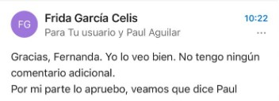

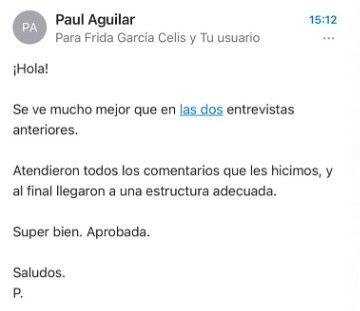